# Kernel Ridge Regression

In this block we:

```
* ...recap the Ridge regression
* ...extend the Ridge regression with a kernel trick
* ...turn the Ridge quantum
```

# Why Ridge Regression?

- The main reason the Ridge regression is used in the ML workflow is to balance the bias-variance trade-off.
- It helps to deal with co-linear data (common issue in Finance)

## Bias-Variance Trade-off

- Consider the general case where we want to predict $Y$ using $X$.
- Assume there is a relationship: $Y=f(X)+\epsilon$, where $\epsilon\sim N(0,\sigma_{\epsilon}^{2})$.
- We model $f(X)$ as $\hat{f}(X)$: How well $\hat{f}(\cdot)$ fits some future random observation $(x_{0},y_{0})$?
  - If $\hat{f}(X)$ is a good model, then $\hat{f}(x_{0})$ should be close to $y_{0}$---this is the notion of prediction error:

$$PE(x_{0})=E[(Y-\hat{f}(x_{0}))^{2}]\,.$$

- Prediction errors can be decomposed into two main components:

### Error due to "Bias'":

∗ The difference between the expected (or average) prediction of our model and the correct value which we are trying to predict.

∗ Bias measures how far off the model prediction is

∗ High bias can cause an algorithm to miss the relevant relations – "underfitting" of the model.

### Error due to "Variance":

∗ The sensitivity of the model to small fluctuations in the training set.

∗ The high variance – the algorithm models complexity in the training data which is due to random noise,

∗ This is also known as model "overfitting".

## Bias-Variance Trade-off

$$ \begin{aligned}PE\left(x_{0}\right) & =E\left[\left(Y-\hat{f}\left(x_{0}\right)\right)^{2}\right]\\ & =E[Y^{2}+\hat{f}(x_{0})^{2}-2Y\hat{f}(x_{0})]\\ & =E[Y^{2}]+E[\hat{f}(x_{0})^{2}]-E[2Y\hat{f}(x_{0})]\\ & =Var[Y]+(E[Y])^{2}+Var[\hat{f}(x_{0})]+(E[\hat{f}(x_{0})])^{2}-2f(x_{0})E[\hat{f}(x_{0})]\\ & =Var[Y]+Var[\hat{f}(x_{0})]+(f(x_{o})-E[\hat{f}(x_{0})])^{2}\\ & =\sigma_{\epsilon}^{2}+Variance+Bias^{2} \end{aligned}$$

- Let us stress that $\sigma_{\epsilon}^{2}$ is the irreducible error
  - Cannot fundamentally be reduced by any model.
  - Given the true model and infinite data to calibrate it, we should be able to reduce both the bias and variance terms to 0.

## Bias-Variance Trade-off

- In practice, there is a trade-off between minimizing the bias and minimizing the variance:
  - As a model becomes more complex (more terms included), local structure/curvature can be picked up
  - Coefficient estimates suffer from high variance as more terms are included in the model.
- This is the fundamental reason underlying the bias-variance trade-off.
- We add cross-validation into our workflow: the method of choice for controlling the bias-variance trade-off
  - We exclude features and test how the generalization improves (not very elegant)
- Regularization is an approach to balance the bias-variance trade-off
  - Smooth approach – we control how much the variables are contributing to the model
  - Hyperparameter to be fine-tuned

## Regularization

- The regularization is a method for solving problems of over-fitting or problems with significant variance.
- The method involves introducing an additional penalty in the form of shrinkage of the coefficient estimates.
- The shrinkage is controlled by an additional parameter
  - Smooth (not necessarily in the mathematical sense) control of the trade-off.
- Generally, an $L_{p}$ regularization is used: $L_{p}=(\sum|\beta_{i}|^{p})^{\frac{1}{p}}$.
  - Every feature has to be normalized to the same scale
- The solution to the OLS is found by minimizing the residual sum of squares (unconstrained optimization):

$$\hat{{\beta}}=\arg\min_{{\beta}'}\text{RSS}=\arg\min_{{\beta}'}\left({y}-{X}{\beta}'\right)^{T}\left(y-{X}{\beta}'\right)\,.$$

- With regularization, we introduce the constrain on the solution:

$$\hat{\beta}=\arg\min_{\beta'}\left(y-X\beta'\right)^{T}\left(y-X\beta'\right)\text{s.t. }L_{p}\left(\beta\right)\leq t\,,$$

where parameter $t$ controls shrinkage and $p$ drives how we constrain the vector of parameters.

## Regularization

- Equivalently, we can rewrite the optimization problem as:

$$\hat{\beta}=\arg\min_{\beta'}\left(y-X{\beta}'\right)^{T}\left(y-X{\beta}'\right)+\lambda L_{p}\left({\beta}\right)\,.$$

where the last term $\lambda L_{p}\left(\beta\right)$ introduces the penalty.

- The more weight we put on the estimated parameters, the more prone we are to increase variance out of the sample.
- Parameter $\lambda$ is a free parameter:
  - If $\lambda=0$, we recover the original OLS solution
  - If $\lambda\to\infty$, the model prefers trivial solution.
- We need to exclude intercept from regularization – re-meaning
- The regularization is known as shrinkage method: The objective is to shrink the estimated parameters and thus control the over-fitting of the model.

## Ridge Regression

- The Ridge Regression is a formulation of the OLS solution with penalty of the form of a $L_{2}$ norm.
- A parameter estimated in this way is also known as a Ridge estimator.
- The Ridge estimator is a solution to the problem:

$$\hat{{\beta}}_{\lambda}^{Ridge}=\arg\min_{{\beta}'}\left(y-X\beta'\right)^{T}\left(y-X\beta'\right)+\lambda\beta^{T}{\beta}\,,$$

where term $\lambda\beta^{T}{\beta}$ corresponds to $L_{2}\left(\beta\right)$ distance.

- We keep the explicit dependence of the estimator on the parameter $\lambda$.
- The solution to the optimization can be written as:

$$\hat{\beta}_{\lambda}^{Ridge}=\left(X^{T}X+\lambda I_{p}\right)^{-1}X^{T}{y}$$

where $I_{p}$ is a unit matrix of dimension $p$.

- The Ridge estimator has a very convenient form – easy to solve as the OLS problem.
  - No extra effort!

## Ridge Regression

- The Ridge was actually introduced for the following reason: The features can be linearly dependent (or perfectly collinear).
  - One feature can be expressed as a linear combination of the others
    - Such feature is redundant (no additional information)
- Consequently: The matrix $X^{T}X$ is not of full rank!
  - The term $\lambda{I}_{p}$ returns the full rank to the matrix and allows for a calculation of the Moore-Penrose pseudoinverse matrix.
  - The parameters can then be solved.
  - A solution to the perfect collinearity in the data – which is linked to our original motivation of fitting the noise
- Equivalently, the Ridge regression is equivalent to the drop out technique
  - Assume we drop an observation with a certain probability $p$.
  - After some manipulations, we end up with the same formulation as with Ridge regression.
- The dropout regularization technique is frequently used for neural networks calibration!

## Ridge Estimator

The Ridge estimator is biased:

$$\begin{aligned}\hat{\beta}_{\lambda}^{Ridge} & =\left(X^{T}X+\lambda I_{p}\right)^{-1}X^{T}{y}\\ & =\left(A+\lambda{I_{p}}\right)^{-1}A\left({A}^{-1}X^{T}y\right)\\ & =[A\left({I_{p}}+\lambda{A}^{-1}\right)]^{-1}{A}[\left(X^{T}{X}\right)^{-1}{X^{T}}{y}]\\ & =\left({I_{p}}+\lambda{A}^{-1}\right)^{-1}{A}^{-1}{A}\hat{\beta}^{OLS}\\ & =\left({I_{p}}+\lambda A^{-1}\right)^{-1}\hat{\beta}^{OLS}E[\hat{\beta}_{\lambda}^{Ridge}]\\ & =\left(I_{p}+\lambda A^{-1}\right)^{-1}\beta \end{aligned}$$

where $A=X^{T}X$ and unless $\lambda=0$, there is a bias in the estimate.

## Ridge Estimator

The variance of the $\hat{\beta}_{\lambda}^{Ridge}$ estimator reads:

$$\begin{aligned}Var[\hat{\beta}_{\lambda}^{Ridge}] & =Var[\left({I_{p}}+\lambda A^{-1}\right)^{-1}\hat{\beta}^{OLS}]\\ & =\left({I_{p}}+\lambda{A}^{-1}\right)^{-1}Var[\hat{\beta}^{OLS}]\left[\left({I_{p}}+\lambda A^{-1}\right)^{-1}\right]^{T}\\ & =\sigma^{2}\left(I_{p}+\lambda A^{-1}\right)^{-1}\left(X^{T}X\right)^{-1}\left[\left(I_{p}+\lambda A^{-1}\right)^{-1}\right]^{T}\\ & =\sigma^{2}[X^{T}X+\lambda{I_{p}}]^{-1}X^{T}X\left([X^{T}X+\lambda I_{p}]^{-1}\right)^{T}\,. \end{aligned}$$

## Ridge Estimator

The bias-variance formula for the $MSE$ of estimators:

$$\begin{aligned}MSE & =E[(\hat{\Theta}-\Theta)^{2}]=E[((\hat{\Theta}-E[\hat{\Theta}])-(\Theta-E[\hat{\Theta}]))^{2}]\\ & =E[\hat{\Theta}-E[\hat{\Theta}]]^{2}+E[(\Theta-E[\hat{\Theta}])^{2}]-2E[(\hat{\Theta}-E[\hat{\Theta}])(\Theta-E[\hat{\Theta}])]\\ & =Var[\hat{\Theta}]+[Bias(\hat{\Theta})]^{2}\,. \end{aligned} $$

- There exists $\lambda^{*}$ such that $MSE[\hat{\beta}_{\lambda^{*}}^{Ridge}]<MSE[\hat{\beta}^{OLS}]$.
  - The Ridge regression is useful almost always.

## Ridge Estimator

- How to identify the value of such $\lambda^{*}$?
  - Assess the performance of the model for a given $\lambda$ out-of-sample (on the testing data set).
  - Cross validation across different set of $\lambda$ values
- For each $\lambda$, calculate $RMSE$ on the testing folds, average the $RMSE$s
- Plot $RMSE$ as a function of $\lambda$ and find the optimum
- The Ridge regression is easy to implement and numerically expensive as the OLS
  - Aside of the cross validation (calculating the Ridge estimator for different values of $\lambda$)
- The Ridge regression shrinks the entire vector of parameters – it balances the entire feature set
- The Ridge regression does not help to select the important features

## Ridge Estimator

- The regularization parameter $\lambda$ is used only during calibration!
  - Once model is learnt and we want to apply it on the data, we do not use $\lambda$
- Use estimates as if they would come from the OLS
  - The model is composed $\beta$s
  - When we recalibrate the model, we employ $\lambda$

```python
# Load what is needed
from sklearn.linear_model import Ridge
from sklearn.metrics import mean_squared_error
import numpy as np
```

```python
# Use boston house price dataset
import pandas as pd
from sklearn.datasets import load_boston

dataBoston = load_boston()

df = pd.DataFrame(dataBoston.data, columns=dataBoston.feature_names)
df['target'] = dataBoston.target
```

[output not shown]

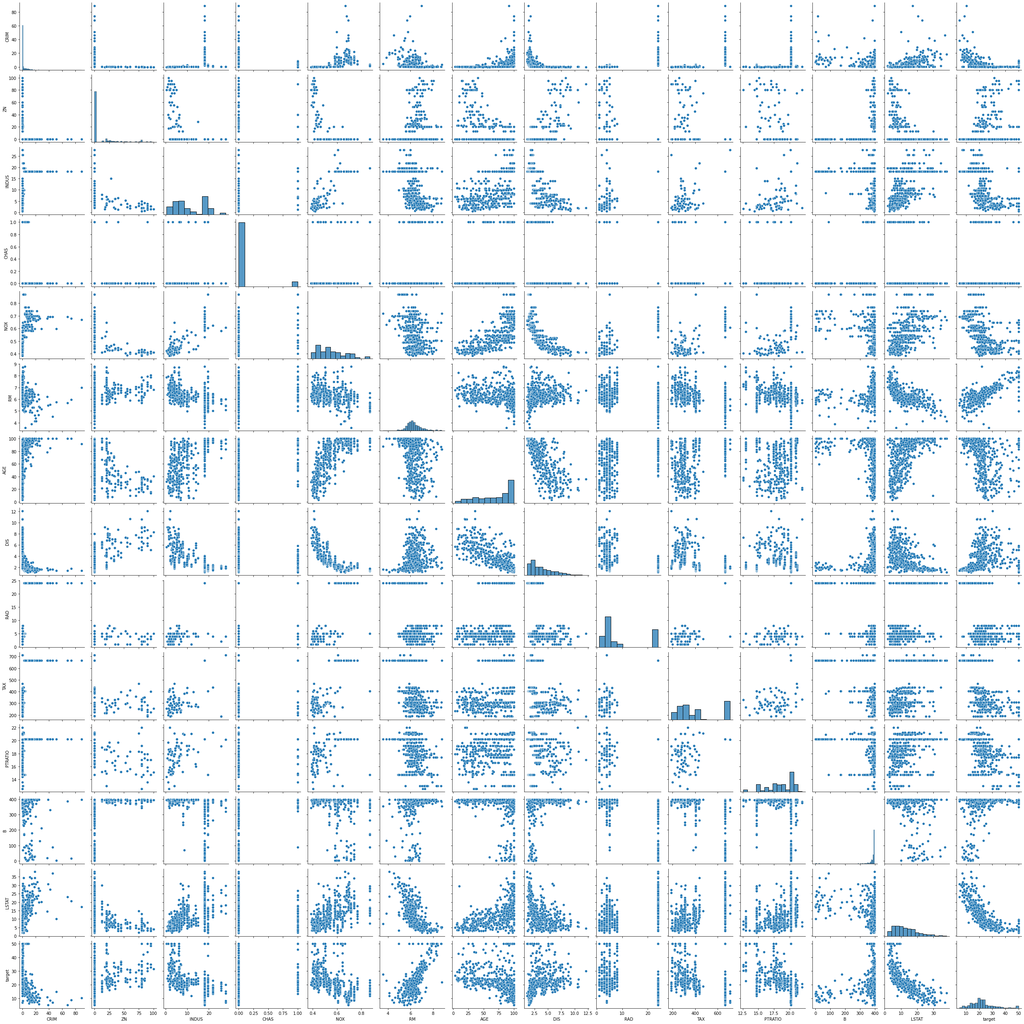

```python
import seaborn as sns
%matplotlib inline
sns.pairplot(df)
```

```python
# Create data arrays
from sklearn.model_selection import train_test_split
from sklearn.pipeline import make_pipeline
from sklearn.preprocessing import StandardScaler

XBoston = dataBoston.data
yBoston = dataBoston.target

XBoston_train, XBoston_test, yBoston_train, yBoston_test = train_test_split(XBoston, yBoston, test_size=0.3, random_state=11)
```

```python
# Explore Ridge
alphaRidgeArray = np.linspace(0.000001,3,30)

ridgeOut = np.empty((0,3), float)

for alphaRidge in alphaRidgeArray:
    # Let us add normalization into the model
    ridge = Ridge(alpha=alphaRidge)
    model = make_pipeline(StandardScaler(with_mean=True,with_std=False), ridge)

    model.fit(XBoston_train,yBoston_train)

    # Run predictions
    yBostonPred_train = model.predict(XBoston_train)
    yBostonPred_test = model.predict(XBoston_test)

    # Get MSE
    mseTrainBoston = mean_squared_error(yBostonPred_train,yBoston_train)
    mseTestBoston = mean_squared_error(yBostonPred_test,yBoston_test)

    # Fill the outcome
    ridgeOut = np.append(ridgeOut,[[alphaRidge,mseTrainBoston,mseTestBoston]],axis = 0)
```

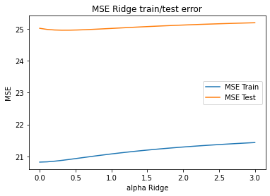

```python
# Visualise
%matplotlib inline
import matplotlib.pyplot as plt
plt.plot(ridgeOut[:,0], ridgeOut[:,1], label = "MSE Train")
plt.plot(ridgeOut[:,0], ridgeOut[:,2], label = "MSE Test")

plt.xlabel('alpha Ridge')
# Set the y axis label of the current axis.
plt.ylabel('MSE')
# Set a title of the current axes.
plt.title('MSE Ridge train/test error')
# show a legend on the plot
plt.legend()
# Display a figure.
plt.show()
```

# Kernel Ridge

We can enhance the Ridge regression with a kernel trick as well.

## Representer Theorem

Let $\Omega:[0,+\infty)\to \Re$ be strictly increasing and let $l:(X\times Y \times \Re)^n$ to $\Re \cup \{+\infty\} $ be a loss function. Further, consider

$$ \min_{f\in H} l(x_i,y_i,f(x_i))+\lambda_n \Omega(||f||^2_H)\,, $$

where $H$ is an reproducing kernel Hilbert space with kernel $K$. Then any optimal solution has the following form:

$$ f(.)=\alpha_iK(.,x_i)\,, $$

with $\alpha_i$ is a data-dependent weight and $K(.,x_i)$ is the kernel function.

We assume a model

$$ y=f(x)+e\,, $$

where $e$ is additive noise and $f$ the regression function. We observe pairs $(x_i,y_i)$ with $i=1,\dots,n$. We seek $f^*$ such that

$$ y_i=f^*(x_i)+e_i\,. $$

Given an reproducing kernel Hilbert space $H$ with kernel $K$, we can solve the problem by

$$ \hat{f}=\arg\min_{f\in H}\frac{1}{2}\sum_{i=1}^{n}(y_i-f(x_i))^2+\frac{\lambda}{2}||f||^2_H\,. $$

Using the representant theorem, we can write the optimisation as:

$$ \hat{\lambda}=\arg\min_{\alpha\in\Re^n}\frac{1}{2}||y-K\alpha||^2_2+\frac{1}{2}\alpha^TK\alpha\,, $$

where matrix $K$ is given as $K_{ij}=K(x_i,x_j)$.

If we solve this for $\alpha$, we get

$$ \hat{\alpha} = (K+\lambda I)^{-1}y. $$

### Ridge regression

We can obtain a Ridge regression we introduced above by setting

$$ K = X X^T\,. $$

This gives

$$ \hat{\alpha} = (XX^T+\lambda I)^{-1}y\,, $$

and

$$ \hat{y}=\hat{f}(z)=\hat{\alpha}^T K z\,. $$

- We have ended up with a kernel from a different angle (not by starting with a transformation of a feature space explicitly).

### Let us focus on examples...

```python
# Import kernel ridge
from sklearn.kernel_ridge import KernelRidge

rng = np.random.RandomState(0)

# Generate sample data
X = 5 * rng.rand(500, 1)
y = np.sin(X).ravel()
noise = np.random.normal(0,0.1,500)

y=y+noise
# Add noise to targets
#y[::5] += 1 * (0.5 - rng.rand(X.shape[0] // 5))

X_plot = np.linspace(0, 5, 500)[:, None]

X_train, X_test, y_train, y_test = train_test_split(X, y, test_size=0.3, random_state=42)
```

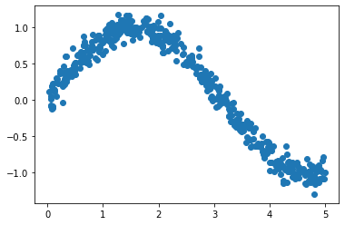

```python
# Plot the data
plt.scatter(X, y, label = "Kernel Ridge data")

# Display a figure.
plt.show()
```

```python
# Kernel Ridge
kr = KernelRidge(kernel="rbf", gamma=1.0, alpha=0.1)
# Fit
kr.fit(X_train, y_train)
```

```
KernelRidge(alpha=0.1, gamma=1.0, kernel='rbf')
```

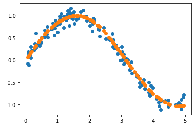

```python
y_predictRBF=kr.predict(X_test)

# Plot

# Plot the data
plt.scatter(X_test, y_test, label = "Kernel Ridge data")
plt.scatter(X_test, y_predictRBF, label = "Kernel Ridge -- prediction")

# Display a figure.
plt.show()
```

We can try different kernel -- polynomial

```python
# Kernel Ridge, polynomial kernel
kr = KernelRidge(kernel="polynomial", degree=6, alpha=0.1)
# Fit
kr.fit(X_train, y_train)
```

```
KernelRidge(alpha=0.1, degree=6, kernel='polynomial')
```

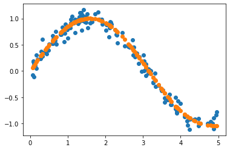

```python
y_predict=kr.predict(X_test)

# Plot

# Plot the data
plt.scatter(X_test, y_test, label = "Kernel Ridge data")
plt.scatter(X_test, y_predict, label = "Kernel Ridge -- prediction")

# Display a figure.
plt.show()
```

Fit without any kernel -- we mimic this by choosing polynomial of degree=1

```python
# Kernel Ridge, polynomial kernel
kr = KernelRidge(kernel="polynomial", degree=1, alpha=0.1)
# Fit
kr.fit(X_train, y_train)
```

```
KernelRidge(alpha=0.1, degree=1, kernel='polynomial')
```

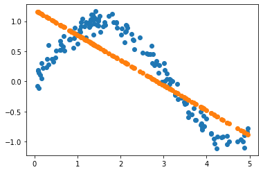

```python
y_predict=kr.predict(X_test)

# Plot

# Plot the data
plt.scatter(X_test, y_test, label = "Kernel Ridge data")
plt.scatter(X_test, y_predict, label = "Kernel Ridge -- prediction")

# Display a figure.
plt.show()
```

## Quantum Kernel

- Let us depict the case with quantum kernel

```python
# Usual Import

# Import basic object from the Qiskit
from qiskit import QuantumCircuit
from qiskit import Aer,BasicAer
from qiskit import execute

# We will need these two
from qiskit.utils import QuantumInstance
from qiskit_machine_learning.kernels import QuantumKernel

# Load account from the disk
from qiskit import IBMQ
IBMQ.load_account()
```

```
<AccountProvider for IBMQ(hub='ibm-q', group='open', project='main')>
```

```python
# Check the version of the qiskit you use

# Compared to previous class, I have installed the up-to-date version
import qiskit.tools.jupyter
%qiskit_version_table
%qiskit_copyright
```

Version Information

| Qiskit Software | Version |
| --- | --- |
| `qiskit-terra` | 0.19.2 |
| `qiskit-aer` | 0.10.3 |
| `qiskit-ignis` | 0.7.0 |
| `qiskit-ibmq-provider` | 0.18.3 |
| `qiskit` | 0.34.2 |
| `qiskit-machine-learning` | 0.3.1 |
| System information |  |
| Python version | 3.8.12 |
| Python compiler | Clang 10.0.0 |
| Python build | default, Oct 12 2021 06:23:56 |
| OS | Darwin |
| CPUs | 4 |
| Memory (Gb) | 8.0 |
| Sun Mar 13 16:35:16 2022 GMT |  |

This code is a part of Qiskit

```python
# Ideal simulator
simulator = Aer.get_backend('qasm_simulator')
```

```python
# Define Feature map, Pauli-Z evolution circuit
from qiskit.circuit.library import ZFeatureMap

# dimension of problem (number of qubits)
nQubits = X.shape[1]
# number of repetitions
nReps = 1


featureMap = ZFeatureMap(feature_dimension=nQubits, reps=nReps)
```

Our example is too trivial for ZZ feature map (there is no entaglement for one qubit). We thus use a simple feature map.

```python
from qiskit.utils import QuantumInstance

backendSim = QuantumInstance(
    BasicAer.get_backend("qasm_simulator"), shots=1024
)
```

```python
# define Quantum kernel using the above feature map
kernelQuantum = QuantumKernel(feature_map=featureMap, quantum_instance=backendSim)
```

```python
krr = KernelRidge(alpha=0.1, kernel="precomputed")
K = kernelQuantum.evaluate(X_train,X_train)
```

```python
krr.fit(K, y_train)
```

```
KernelRidge(alpha=0.1, kernel='precomputed')
```

```python
K_test = kernelQuantum.evaluate(X_test,X_train)
y_Qpredict = krr.predict(K_test)
```

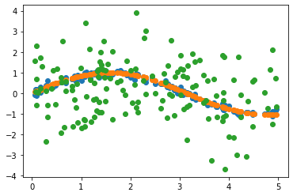

```python
# Plot the data
plt.scatter(X_test, y_test, label = "Kernel Ridge data")
plt.scatter(X_test, y_predictRBF, label = "Kernel Ridge -- prediction")
plt.scatter(X_test, y_Qpredict, label = "Kernel Ridge -- quantum kernel prediction")

# Display a figure.
plt.show()
```

## Improvements

- GridSearch of metaparameters
- Try different models and parametrisation
- Regularise